# A Data Cleansing and Visualization Project in Python

**by Bernardo Di Chiara**

*November 6th 2018*

This project consists in formulating a set of research questions and then searching and importing two data sets from Internet that could help to answer those questions.

The data sets are cleansed and manipulated by using Pandas library.

Then, some exploratory data analysis is performed and plots are created by using Matplotlib library. When creating those plots, graphical heuristics like Edward Tufte data-ink ratio and Alberto Cairo's principles are followed in order to produce visualizations that are truthful, functional, insightful and pleasant to the eye.

The data manipulation process is done by Python programming as much as possible.

## 1. Research Questions

Based on information released by Eurostat (the European statistical institution), Finns are quite satisfied about the way they use their time [[1]](https://ec.europa.eu/eurostat/statistics-explained/index.php?title=File:Satisfaction_with_time_use,_by_country,_2013.png). On the other hand, Germans are among the less satisfied ones.

[figure not shown]

This paper focus on the way Finns use their time, on the differences between men and women and on the changes of those figures over time. Comparison with data related to Germany is done.

The questions that we are trying to answer are:

- How much time Finns spend on average working? How much on free time?
- What are the differences between men and women? How those values have been changing over time?
- How those values differ from values related to Germany?

## 2. Used Data

The two data sets used in this project are part of the harmonised European time use survey carried out in several European countries, whose scope is the resident population of the country living in private households ('). The data has been collected through an interview survey by using randomly selected samples. Samples' sizes have been defined in order to be representative of the population in the respective countries (over 5000 people have been included for Finland which has a population over 5 millions whereas for Germany, which has a population over 70.000, a sample of over 12000 people has been defined).

Respondents have been asked to keep an accurate diary of their time use over a two-days period. The diary period has been randomly designated and defined so to cover a full 12 months consecutive period. The survey examines working time, the time used on domestic work, sleeping and eating, leisure time activities and the time spent with other people as well as the place of activity. In addition, the survey also studies the rhythms of time use according to day, day of the week and season.

The activities described by the respondents themselves are coded according to a 146-category classification of work activities. Background variables for the time use data are such as the main type of activity, age, stage in life, level of education, socio-economic group, type of municipality, major region, province, time of the year, day of the week.

The first used data set [[2]](http://pxnet2.stat.fi/PXWeb/pxweb/en/StatFin/StatFin__eli__akay/statfin_akay_pxt_001.px/?rxid=61842c9f-cc06-4b6a-afeb-011d96554479) is publicly available from Statistics Finland (Tilastokeskus), the national statistical institution in Finland.

It contains information about how people use their time, differentiated by gender, according to four different surveys run at a distance of approximately 10 years (starting in 1979, 1987, 1999 and 2009). In this data set, day activities have been divided in 26 different categories.

The second data set [[3]](https://ec.europa.eu/eurostat/documents/3930297/5953614/KS-58-04-998-EN.PDF/c789a2ce-ed5b-4a0c-bcbf-693e699db7d7?version=1.0) is available from Eurostat, the European statistical institution. It contains similar data from other nine European countries. The data contained in tables 1.1 and 1.2 is used in this project and in particular the columns related to Germany. Data related to this Country has been collected in years 2001-2002.

Additional information about those surveys can be found in the document "Comparable time use statistics. National tables from 10 European countries" [[4]](https://ec.europa.eu/eurostat/web/products-statistical-working-papers/-/KS-CC-05-001)

<sub>(') European guidelines for such surveys [[5]](https://ec.europa.eu/eurostat/documents/3859598/5909673/KS-RA-08-014-EN.PDF/a745ca2e-7dc6-48a9-a36c-000ad120380e?version=1.0) can be found at the link visible in the References section.</sub>

### 2.1. References

[1] Satisfaction with time use, by country  
https://ec.europa.eu/eurostat/statistics-explained/index.php?title=File:Satisfaction_with_time_use,_by_country,_2013.png

[2] Time use in Finland  
http://pxnet2.stat.fi/PXWeb/pxweb/en/StatFin/StatFin__eli__akay/statfin_akay_pxt_001.px/?rxid=61842c9f-cc06-4b6a-afeb-011d96554479

[3] Time use in Europe  
https://ec.europa.eu/eurostat/documents/3930297/5953614/KS-58-04-998-EN.PDF/c789a2ce-ed5b-4a0c-bcbf-693e699db7d7?version=1.0

[4] Comparable time use statistics. National tables from 10 European countries  
https://ec.europa.eu/eurostat/web/products-statistical-working-papers/-/KS-CC-05-001

[5] Harmonised European time use surveys guidelines  
https://ec.europa.eu/eurostat/documents/3859598/5909673/KS-RA-08-014-EN.PDF/a745ca2e-7dc6-48a9-a36c-000ad120380e?version=1.0

## 3. Setup and Retrieving Data

```python
### Importing the needed libraries
import numpy as np
import pandas as pd
import matplotlib.pyplot as plt
### First data set: Importing the excel file as a dataframe
filename = 'Time_use_in_Finland.xlsx'
timeuse = pd.read_excel(filename, sheet_name='akay_001_200900', na_values = '.', skiprows = [1, 2], skipfooter = 29)
# Values containing a period have been handled as NA
# Non relevant rows at the beginning and at the end of the file have been omitted
### Second data set: Creating the dataset by copying the info from table 1.1 and 1.2 related to Germany (data collected from 2001 and 2002)
row1 = pd.Series({'Women':'5:24', 'Men': '5:53'})
row2 = pd.Series({'Women':'2:43', 'Men': '2:33'})
row3 = pd.Series({'Women':'8:19', 'Men': '8:12'})
row4 = pd.Series({'Women':'1:18', 'Men': '1:27'})
row5 = pd.Series({'Women':'4:11', 'Men': '2:21'})
row6 = pd.Series({'Women':'2:05', 'Men': '3:35'})
timeuse_germany = pd.DataFrame([row1, row2, row3, row4, row5, row6], index = ['Free time & Unspecified', 'Personal care', 'Sleep', 'Travel', 'Domestic work', 'Gainful employment & Study'])
```

## 4. Data Cleansing and Preparation

### 4.1. Second Data Set

```python
### Adding the seconds' substring and then changing the format to timedelta
## For each column
for i in list(range(0, 2)):
    # For each row
    for j in list(range(0, len(timeuse_germany))):
        # Append the seconds' substring
        timeuse_germany.iloc[j, i] = timeuse_germany.iloc[j, i] + ':00'
    # Change the format to timedelta
    timeuse_germany[timeuse_germany.columns[i]] = pd.to_timedelta(timeuse_germany[timeuse_germany.columns[i]])
### Creating a new indipendent dataframe containing time information in minutes
timeuse_germany_min = timeuse_germany.copy()
for i in list(range(0, 2)):
    for j in list(range(0, len(timeuse_germany))):
        timeuse_germany_min.iloc[j, i] =  timeuse_germany_min.iloc[j, i].total_seconds()/60
### Creating a new dataframe containing the corresponding percentage values (rounded with 2 decimal digits)
### and adding a column for the total population (men and women)
timeuse_germany_min_perc = timeuse_germany_min.copy()
for i in list(range(0, 2)):
    for j in list(range(0, len(timeuse_germany_min))):
        timeuse_germany_min_perc.iloc[j, i] =  round(timeuse_germany_min_perc.iloc[j, i]/14.4, 2)
## Renaming the columns to indicate the percentage value
for i in list(range(0, 2)):
    timeuse_germany_min_perc = timeuse_germany_min_perc.rename(columns={timeuse_germany_min_perc.columns[i]: timeuse_germany_min_perc.columns[i] + '_%'})
## Adding the total column
timeuse_germany_min_perc['Total_%'] = round((timeuse_germany_min_perc['Women_%'] + timeuse_germany_min_perc['Men_%'])/2, 2)
# Fixing rounding errors
timeuse_germany_min_perc.iloc[0] = round(100.00 - timeuse_germany_min_perc.iloc[1] -timeuse_germany_min_perc.iloc[2] - timeuse_germany_min_perc.iloc[3] - timeuse_germany_min_perc.iloc[4] - timeuse_germany_min_perc.iloc[5], 2)
timeuse_germany_min_perc
```

|  | Women_% | Men_% | Total_% |
| --- | --- | --- | --- |
| Free time & Unspecified | 22.50 | 24.45 | 23.48 |
| Personal care | 11.32 | 10.62 | 10.97 |
| Sleep | 34.65 | 34.17 | 34.41 |
| Travel | 5.42 | 6.04 | 5.73 |
| Domestic work | 17.43 | 9.79 | 13.61 |
| Gainful employment & Study | 8.68 | 14.93 | 11.80 |

### 4.2. First Data Set

```python
### Fixing column names
## Renaming the columns by using the infomation of the first two rows
timeuse.columns.values[0] = 'Category'
timeuse = timeuse.rename(columns={
    'Unnamed: 1':'TmUs_Total_1979',
    'Unnamed: 2':'TmUs_Total_1987',
    'Unnamed: 3':'TmUs_Total_1999',
    'Unnamed: 4':'TmUs_Total_2009',
    'Unnamed: 5':'TmUs_Man_1979',
    'Unnamed: 6':'TmUs_Man_1987',
    'Unnamed: 7':'TmUs_Man_1999',
    'Unnamed: 8':'TmUs_Man_2009',
    'Unnamed: 9':'TmUs_Woman_1979',
    'Unnamed: 10':'TmUs_Woman_1987',
    'Unnamed: 11':'TmUs_Woman_1999',
    'Unnamed: 12':'TmUs_Woman_2009',
    'Unnamed: 13':'Part_Total_1979',
    'Unnamed: 14':'Part_Total_1987',
    'Unnamed: 15':'Part_Total_1999',
    'Unnamed: 16':'Part_Total_2009',
    'Unnamed: 17':'Part_Man_1979',
    'Unnamed: 18':'Part_Man_1987',
    'Unnamed: 19':'Part_Man_1999',
    'Unnamed: 20':'Part_Man_2009',
    'Unnamed: 21':'Part_Woman_1979',
    'Unnamed: 22':'Part_Woman_1987',
    'Unnamed: 23':'Part_Woman_1999',
    'Unnamed: 24':'Part_Woman_2009',
                                  })
## Removing the first two rows
timeuse = timeuse.drop([0, 1])
### Changing cell contents
# Fixing the anomalies in the description of the fifth category (space was before the comma rather than after)
timeuse['Category'] = timeuse['Category'].replace({'03-08  Domestic work ,total' : '03-08  Domestic work, total'})
### Moving the column Category as an index
timeuse = timeuse.set_index(timeuse.columns[0])
### Changing the data types of the columns and the appearance of time data
## Ensuring all the values are in mumerical format
for i in list(range(0, 24)):
    timeuse[timeuse.columns[i]] = pd.to_numeric(timeuse[timeuse.columns[i]])
## For each of the first 12 columns
for i in list(range(0, 12)):
    # Change the type to string
    timeuse[timeuse.columns[i]] = timeuse[timeuse.columns[i]].apply(str)
    # Replace the period with semicolon
    timeuse[timeuse.columns[i]] = timeuse[timeuse.columns[i]].str.replace('.', ':')
    # Adding a 0 digit to all the entries that have only one digit after the semicolon
    # (in order to make a correct conversion to time format) and append the seconds substring
    # For each row
    for j in list(range(0, len(timeuse))):
        # Find the semicolon in the string
        string = timeuse.iloc[j, i]
        pos = string.find(':')
        # Add a 0 digit if there is no second digit after the semicolon
        try:
            sec_dig = string[pos+2]
        except: timeuse.iloc[j, i] = string + '0'
        # Append the seconds substring
        timeuse.iloc[j, i] = timeuse.iloc[j, i] + ':00'
    # Change the format to timedelta
    timeuse[timeuse.columns[i]] = pd.to_timedelta(timeuse[timeuse.columns[i]])
### Creating a new indipendent dataframe containing only time information in minutes
timeuse_min = timeuse[timeuse.columns[list(range(0, 12))]].copy()
for i in list(range(0, 12)):
    for j in list(range(0, len(timeuse))):
        timeuse_min.iloc[j, i] =  timeuse_min.iloc[j, i].total_seconds()/60
### Creating a new dataframe containing the corresponding percentage values
timeuse_min_perc = timeuse_min.copy()
for i in list(range(0, 12)):
    for j in list(range(0, len(timeuse_min))):
        timeuse_min_perc.iloc[j, i] =  timeuse_min_perc.iloc[j, i]/14.4
## Renaming the columns to indicate the percentage value
for i in list(range(0, 12)):
    timeuse_min_perc = timeuse_min_perc.rename(columns={timeuse_min_perc.columns[i]: timeuse_min_perc.columns[i] + '_%'})
### Creating a new dataframe with data from the first data set by using new categories
### that are alligned with the categories used in the second data set
# Combining '15-25 Free time, total' and '26 Unspecified' without including '25 Travel related to free time' into 'Free time & Unspecified'
dfrow1 = timeuse_min_perc.iloc[19] + timeuse_min_perc.iloc[31] - timeuse_min_perc.iloc[30]
# '09-11  Personal care, total' without '09 Sleep' into 'Personal care'
dfrow2 = timeuse_min_perc.iloc[11] - timeuse_min_perc.iloc[12]
# '09 Sleep' into 'Sleep'
dfrow3 = timeuse_min_perc.iloc[12]
# Combining all travel activities ('08 Travel related to domestic work', '13 Travel related to study', '25 Travel related to free time')
# except travel related to work into 'Travel'
dfrow4 = timeuse_min_perc.iloc[10] + timeuse_min_perc.iloc[17] + timeuse_min_perc.iloc[30]
# '03-08 Domestic work, total' without '08 Travel related to domestic work' into 'Domestic work'
dfrow5 = timeuse_min_perc.iloc[4] - timeuse_min_perc.iloc[10]
# Combining '01-02 Gainful employment, total' and '12-14 Study, total' without including '13 Travel related to study' into 'Gainful employment & Study'
dfrow6 = timeuse_min_perc.iloc[1] + timeuse_min_perc.iloc[15] - timeuse_min_perc.iloc[17]
TmUs_fin_grouped = pd.DataFrame([dfrow1, dfrow2, dfrow3, dfrow4, dfrow5, dfrow6], index = ['Free time & Unspecified', 'Personal care', 'Sleep', 'Travel', 'Domestic work', 'Gainful employment & Study'])
## Rouding all values at 2 digit decimal
# For each column
for i in list(range(0, 12)):
    # For each row
    for j in list(range(0, len(TmUs_fin_grouped))):
        TmUs_fin_grouped.iloc[j, i] = round(TmUs_fin_grouped.iloc[j, i], 2)
# Fixing rounding errors
TmUs_fin_grouped.iloc[0] = round(100.00 - TmUs_fin_grouped.iloc[1] - TmUs_fin_grouped.iloc[2] - TmUs_fin_grouped.iloc[3] - TmUs_fin_grouped.iloc[4] - TmUs_fin_grouped.iloc[5], 2)
TmUs_fin_grouped
```

|  | TmUs_Total_1979_% | TmUs_Total_1987_% | TmUs_Total_1999_% | TmUs_Total_2009_% | TmUs_Man_1979_% | TmUs_Man_1987_% | TmUs_Man_1999_% | TmUs_Man_2009_% | TmUs_Woman_1979_% | TmUs_Woman_1987_% | TmUs_Woman_1999_% | TmUs_Woman_2009_% |
| --- | --- | --- | --- | --- | --- | --- | --- | --- | --- | --- | --- | --- |
| Free time & Unspecified | 21.88 | 22.22 | 22.64 | 25.06 | 23.19 | 22.92 | 24.03 | 27.15 | 20.63 | 21.26 | 21.12 | 22.98 |
| Personal care | 8.61 | 8.26 | 8.33 | 9.03 | 8.54 | 8.40 | 8.12 | 8.68 | 8.54 | 8.19 | 8.61 | 9.38 |
| Sleep | 35.42 | 35.00 | 35.35 | 35.49 | 35.49 | 35.00 | 35.00 | 35.28 | 35.35 | 35.00 | 35.69 | 35.69 |
| Travel | 3.12 | 3.89 | 3.82 | 3.68 | 3.33 | 4.03 | 3.75 | 3.54 | 3.12 | 3.82 | 3.96 | 3.82 |
| Domestic work | 10.76 | 10.35 | 10.62 | 10.42 | 6.88 | 7.15 | 7.36 | 8.06 | 14.37 | 13.61 | 13.68 | 12.85 |
| Gainful employment & Study | 20.21 | 20.28 | 19.24 | 16.32 | 22.57 | 22.50 | 21.74 | 17.29 | 17.99 | 18.12 | 16.94 | 15.28 |

### 4.3. Defining the List of Time Use Categories

```python
### Defining a list that contains the categories
categories = TmUs_fin_grouped.index.tolist()
# Inserting the string 0 at index 0 in the list category
# (since for some reason the yticklabels in the plots below starts with index 1)
categories.insert(0, '0')
categories
```

```
['0',
 'Free time & Unspecified',
 'Personal care',
 'Sleep',
 'Travel',
 'Domestic work',
 'Gainful employment & Study']
```

## 5. Exploratory Data Analysis

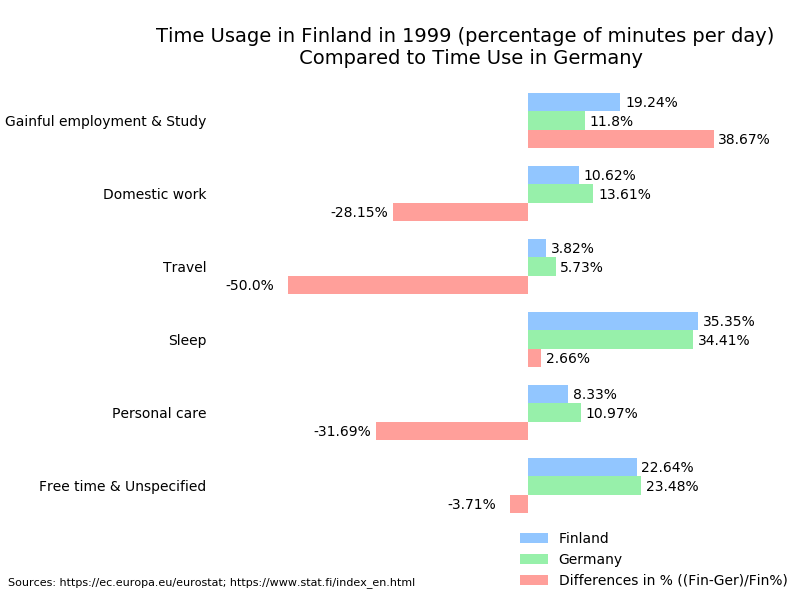

```
Text(0.01,0.025,'Sources: https://ec.europa.eu/eurostat; https://www.stat.fi/index_en.html')
```

```python
%matplotlib notebook
### Creating a bar plot for Total Time Usage in 1999, grouped categories
## Figure type and format
# Creating a new figure
fig = plt.figure(figsize=(8,6))
# Defining the used style
plt.style.use('seaborn-pastel')
# Removing the frame of the chart
for spine in plt.gca().spines.values():
    spine.set_visible(False)
# Adjusting the position of the y axis to leave space for y values
fig.subplots_adjust(left=0.27)
## Main plotted data
# Defining bar width (vertical dimension)
bars_width = 1/4.
# Preparing difference data
diff = round((TmUs_fin_grouped['TmUs_Total_1999_%'] - timeuse_germany_min_perc['Total_%'])/TmUs_fin_grouped['TmUs_Total_1999_%']*100, 2)
# Defining a horizontal bar plot with multiple side by side bars (Finnish data, German data and percent differences)
bars_f = plt.barh([x + bars_width for x in range(len(TmUs_fin_grouped))], TmUs_fin_grouped['TmUs_Total_1999_%'], height = bars_width)
bars_g = plt.barh([x for x in range(len(timeuse_germany_min_perc))], timeuse_germany_min_perc['Total_%'], height = bars_width)
bars_diff = plt.barh([x - bars_width for x in range(len(diff))], diff, height = bars_width)
# Adding the value of the mean values in the plot close to each bar
for bar in bars_f:
    plt.gca().text(bar.get_width() + 1, bar.get_y() + bar.get_height()/2 - 0.07, str(str(bar.get_width()) + '%'), fontsize=10)
for bar in bars_g:
    plt.gca().text(bar.get_width() + 1, bar.get_y() + bar.get_height()/2 - 0.07, str(str(bar.get_width()) + '%'), fontsize=10)
for bar in bars_diff:
    if bar.get_width() >= 0:
        plt.gca().text(bar.get_width() + 1, bar.get_y() + bar.get_height()/2 - 0.07, str(str(bar.get_width()) + '%'), fontsize=10)
    if bar.get_width() < 0:
        plt.gca().text(bar.get_width() - 13, bar.get_y() + bar.get_height()/2 - 0.07, str(str(bar.get_width()) + '%'), fontsize=10)
## Adding a title
plt.title('Time Usage in Finland in 1999 (percentage of minutes per day) \n Compared to Time Use in Germany', fontsize=14)
## Formatting the axses
# Defining the limits of the x axis
plt.gca().set_xlim(-65, 40)
# Removing ticks and values in the x axis
plt.gca().axes.get_xaxis().set_visible(False)
# Removing y axis ticks
plt.gca().yaxis.set_ticks_position('none')
# Defining y axis tick values
plt.gca().set_yticklabels(categories, fontsize=10)
## Adding a legend
fig.legend(['Finland', 'Germany', 'Differences in % ((Fin-Ger)/Fin%)'], frameon=False, fontsize=10, loc = 4)
## Adding a text box under the figure to indicate the data source
textstr = 'Sources: https://ec.europa.eu/eurostat; https://www.stat.fi/index_en.html'
plt.gcf().text(0.01, 0.025, textstr, fontsize=8)
```

The plot above shows the average time (in percentage of the time of a day) used for the total population (Finnish man and women living in private households) in year 1999/2000 for different grouped categories of activities (blue bars). It also shows similar data for Germans (green bars) and the differences of Finnish data and German data in percentage of Finnish data (red bars).

On average Finns spent over 22.64% of the time for free activities and 19.24% of the time for work and study related activities. Those figures are the estimated averages of the all population.

The largest differences with data from Germany in percentage compared to Finnish data is the time spent for non-work-related travel that is 3.82 for Finns and 5.73% for Germans (50% more). The next big difference is the time spent for work related activities that is 19.24% for Finns and only 11.8 for Germans (38.67% less). Finns spend also 31.69% less time in personal care (8.33%) compared to Germans (10.97%).

So the quite counter-intuitive result is that there is an association between the group that states to be more satisfied with the usage of their time and the group that works more, travels less for leisure or domestic work and spends less time for personal care like eating.

It shall be noted that, due to the observational nature of the original research, it is not possible to deduce any causal relationship. Usage of time is only one possible variable that can be associated with the stated satisfaction level about using own time. Other factors might include, for example, a prevalence of assertive kind of personalities among Finns.

Also, in order to verify whether these differences are statistically relevant, inference methods would need to be used. In order to use those methods, it would be necessary to get more statistical data about the variability of the distributions.

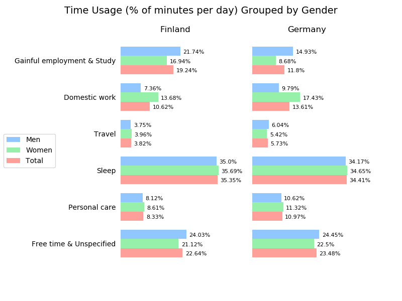

```python
%matplotlib notebook

### Creating a bar plot for Time Usage in 1999, grouped categories, differentiating man and women data

## Figure high level format
# Create 2x2 grid of axis subplots
fig, (ax1, ax2) = plt.subplots(1, 2, sharex=True, sharey=True, figsize=(8,6))
axs = [ax1,ax2]
# Adjusting the position of the y axis to leave space for y values
fig.subplots_adjust(left=0.3)

## Left plot type and format
plt.sca(axs[0])
# Defining the used style
plt.style.use('seaborn-pastel')
# Removing the frame of the chart
for spine in plt.gca().spines.values():
    spine.set_visible(False)

## Right plot type and format
plt.sca(axs[1])
# Defining the used style
plt.style.use('seaborn-pastel')
# Removing the frame of the chart
for spine in plt.gca().spines.values():
    spine.set_visible(False)

## Main plotted data
# Defining y values
yindexses = range(len(TmUs_fin_grouped))
# Defining bar width (vertical dimension)
bars_width = 1/4.
# Defining a horizontal bar plot with multiple side by side bars, Finland (left plot)
bars_f_m = ax1.barh([x + bars_width for x in range(len(TmUs_fin_grouped))], TmUs_fin_grouped['TmUs_Man_1999_%'], height = bars_width)
bars_f_w = ax1.barh([x for x in range(len(TmUs_fin_grouped))], TmUs_fin_grouped['TmUs_Woman_1999_%'], height = bars_width)
bars_f_t = ax1.barh([x - bars_width for x in range(len(TmUs_fin_grouped))], TmUs_fin_grouped['TmUs_Total_1999_%'], height = bars_width)
# Defining a horizontal bar plot with multiple side by side bars, Germany (right plot)
bars_g_m = ax2.barh([x + bars_width for x in range(len(timeuse_germany_min_perc))], timeuse_germany_min_perc['Men_%'], height = bars_width)
bars_g_w = ax2.barh([x for x in range(len(timeuse_germany_min_perc))], timeuse_germany_min_perc['Women_%'], height = bars_width)
bars_g_t = ax2.barh([x - bars_width for x in range(len(timeuse_germany_min_perc))], timeuse_germany_min_perc['Total_%'], height = bars_width)
# Adding the value of the mean values in the plot close to each bar
plt.sca(axs[0]) # Left plot
for bar in bars_f_m:
    plt.gca().text(bar.get_width() + 1, bar.get_y() + bar.get_height()/2 - 0.07, str(str(bar.get_width()) + '%'), fontsize=8)
for bar in bars_f_w:
    plt.gca().text(bar.get_width() + 1, bar.get_y() + bar.get_height()/2 - 0.07, str(str(bar.get_width()) + '%'), fontsize=8)
for bar in bars_f_t:
    plt.gca().text(bar.get_width() + 1, bar.get_y() + bar.get_height()/2 - 0.07, str(str(bar.get_width()) + '%'), fontsize=8)
plt.sca(axs[1]) # Right plot
for bar in bars_g_m:
    plt.gca().text(bar.get_width() + 1, bar.get_y() + bar.get_height()/2 - 0.07, str(str(bar.get_width()) + '%'), fontsize=8)
for bar in bars_g_w:
    plt.gca().text(bar.get_width() + 1, bar.get_y() + bar.get_height()/2 - 0.07, str(str(bar.get_width()) + '%'), fontsize=8)
for bar in bars_g_t:
    plt.gca().text(bar.get_width() + 1, bar.get_y() + bar.get_height()/2 - 0.07, str(str(bar.get_width()) + '%'), fontsize=8)

## Adding titles
fig.suptitle('Time Usage (% of minutes per day) Grouped by Gender', fontsize=14)
ax1.set_title('Finland', fontsize=12)
ax2.set_title('Germany', fontsize=12)

## Formatting the axses of the left plot
plt.sca(axs[0])
# Defining the limits of the x axis
plt.gca().set_xlim(0, 60)
# Removing ticks and values in the x axis
plt.gca().axes.get_xaxis().set_visible(False)
# Removing y axis ticks
plt.gca().yaxis.set_ticks_position('none')
# Defining y axis tick values
plt.gca().set_yticklabels(categories, fontsize=10)
## Formatting the axses of the right plot
plt.sca(axs[1])
# Defining the limits of the x axis
plt.gca().set_xlim(0, 40)
# Removing ticks and values in the x axis
plt.gca().axes.get_xaxis().set_visible(False)
# Removing y axis ticks
plt.gca().yaxis.set_ticks_position('none')

## Adding a legend
fig.legend(['Men', 'Women', 'Total'], fontsize=10, loc = 6)
```

In the plot above information related to man and women groups has been added.

The main differences among genders seem in work and study related time with women having less of it compared to men. Women have also less free time and spend more time in domestic work.

Those results were expected even in a quite egalitarian society as Finnish society.

German data show the same trend.

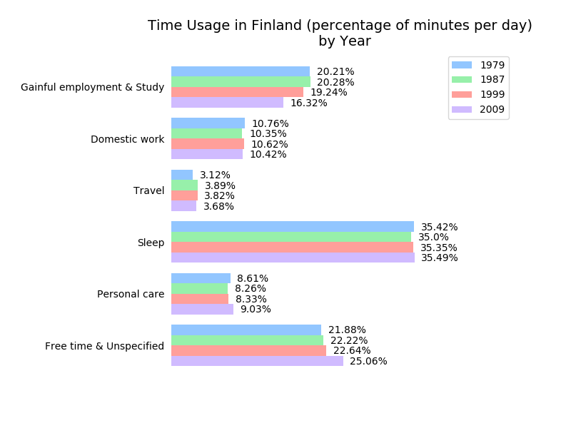

```python
%matplotlib notebook
### Creating a bar plot for Time Usage in Finland, grouped categories, differentiating between different survey periods
## Figure type and format
# Creating a new figure
fig = plt.figure(figsize=(8,6))
# Defining the used style
plt.style.use('seaborn-pastel')
# Removing the frame of the chart
for spine in plt.gca().spines.values():
    spine.set_visible(False)
# Adjusting the position of the y axis to leave space for y values
fig.subplots_adjust(left=0.3)
## Main plotted data
# Defining y values
yindexses = range(len(TmUs_fin_grouped))
# Defining bar width (vertical dimension)
bars_width = 1/5.
# Defining a horizontal bar plot with multiple side by side bars
bars_1 = plt.barh([x + bars_width*3/2 for x in list(yindexses)], TmUs_fin_grouped['TmUs_Total_1979_%'], height = bars_width)
bars_2 = plt.barh([x + bars_width/2 for x in list(yindexses)], TmUs_fin_grouped['TmUs_Total_1987_%'], height = bars_width)
bars_3 = plt.barh([x - bars_width/2 for x in list(yindexses)], TmUs_fin_grouped['TmUs_Total_1999_%'], height = bars_width)
bars_4 = plt.barh([x - bars_width*3/2 for x in list(yindexses)], TmUs_fin_grouped['TmUs_Total_2009_%'], height = bars_width)
# Adding the value of the mean values in the plot close to each bar
for bar in bars_1:
    plt.gca().text(bar.get_width() + 1, bar.get_y() + bar.get_height()/2 - 0.07, str(str(bar.get_width()) + '%'), fontsize=10)
for bar in bars_2:
    plt.gca().text(bar.get_width() + 1, bar.get_y() + bar.get_height()/2 - 0.07, str(str(bar.get_width()) + '%'), fontsize=10)
for bar in bars_3:
    plt.gca().text(bar.get_width() + 1, bar.get_y() + bar.get_height()/2 - 0.07, str(str(bar.get_width()) + '%'), fontsize=10)
for bar in bars_4:
    plt.gca().text(bar.get_width() + 1, bar.get_y() + bar.get_height()/2 - 0.07, str(str(bar.get_width()) + '%'), fontsize=10)
## Adding a title
plt.title('Time Usage in Finland (percentage of minutes per day) \n by Year', fontsize=14)
## Formatting the axses
# Defining the limits of the x axis
plt.gca().set_xlim(0, 50)
# Removing ticks and values in the x axis
plt.gca().axes.get_xaxis().set_visible(False)
# Removing y axis ticks
plt.gca().yaxis.set_ticks_position('none')
# Defining y axis tick values
plt.gca().set_yticklabels(categories, fontsize=10)
## Adding a legend
plt.legend(['1979', '1987', '1999', '2009'], fontsize=10)
```

The previous plot shows how time usage in Finland has been changing over the decades.

The time used for working and studying has decreased in the last two survey periods. In the last survey period we also notice an increase in free time.

In order to investigate if those differences are statistically relevant, inferential statistics should be applied but this is outside the scope of this paper.

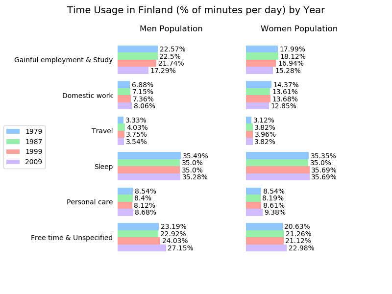

```python
### Creating a grid plot with due subplots containing information about different survey  periods
### differentiated for man and women

## Figure high level format
# Create 2x2 grid of axis subplots
fig, (ax1, ax2) = plt.subplots(1, 2, sharex=True, sharey=True, figsize=(8,6))
axs = [ax1,ax2]
# Adjusting the position of the y axis to leave space for y values
fig.subplots_adjust(left=0.3)

## Left plot type and format
plt.sca(axs[0])
# Defining the used style
plt.style.use('seaborn-pastel')
# Removing the frame of the chart
for spine in plt.gca().spines.values():
    spine.set_visible(False)

## Right plot type and format
plt.sca(axs[1])
# Defining the used style
plt.style.use('seaborn-pastel')
# Removing the frame of the chart
for spine in plt.gca().spines.values():
    spine.set_visible(False)

## Main plotted data
# Defining y values
yindexses = range(len(TmUs_fin_grouped))
# Defining bar width (vertical dimension)
bars_width = 1/5.
# Defining a horizontal bar plot with multiple side by side bars, men (left plot)
bars_1_m = ax1.barh([x + bars_width*3/2 for x in list(yindexses)], TmUs_fin_grouped['TmUs_Man_1979_%'], height = bars_width)
bars_2_m = ax1.barh([x + bars_width/2 for x in list(yindexses)], TmUs_fin_grouped['TmUs_Man_1987_%'], height = bars_width)
bars_3_m = ax1.barh([x - bars_width/2 for x in list(yindexses)], TmUs_fin_grouped['TmUs_Man_1999_%'], height = bars_width)
bars_4_m = ax1.barh([x - bars_width*3/2 for x in list(yindexses)], TmUs_fin_grouped['TmUs_Man_2009_%'], height = bars_width)
# Defining a horizontal bar plot with multiple side by side bars, women (right plot)
bars_1_w = ax2.barh([x + bars_width*3/2 for x in list(yindexses)], TmUs_fin_grouped['TmUs_Woman_1979_%'], height = bars_width)
bars_2_w = ax2.barh([x + bars_width/2 for x in list(yindexses)], TmUs_fin_grouped['TmUs_Woman_1987_%'], height = bars_width)
bars_3_w = ax2.barh([x - bars_width/2 for x in list(yindexses)], TmUs_fin_grouped['TmUs_Woman_1999_%'], height = bars_width)
bars_4_w = ax2.barh([x - bars_width*3/2 for x in list(yindexses)], TmUs_fin_grouped['TmUs_Woman_2009_%'], height = bars_width)
# Adding the value of the mean values in the plot close to each bar
plt.sca(axs[0]) # Left plot
for bar in bars_1_m:
    plt.gca().text(bar.get_width() + 1, bar.get_y() + bar.get_height()/2 - 0.07, str(str(bar.get_width()) + '%'), fontsize=10)
for bar in bars_2_m:
    plt.gca().text(bar.get_width() + 1, bar.get_y() + bar.get_height()/2 - 0.07, str(str(bar.get_width()) + '%'), fontsize=10)
for bar in bars_3_m:
    plt.gca().text(bar.get_width() + 1, bar.get_y() + bar.get_height()/2 - 0.07, str(str(bar.get_width()) + '%'), fontsize=10)
for bar in bars_4_m:
    plt.gca().text(bar.get_width() + 1, bar.get_y() + bar.get_height()/2 - 0.07, str(str(bar.get_width()) + '%'), fontsize=10)
plt.sca(axs[1]) # Right plot
for bar in bars_1_w:
    plt.gca().text(bar.get_width() + 1, bar.get_y() + bar.get_height()/2 - 0.07, str(str(bar.get_width()) + '%'), fontsize=10)
for bar in bars_2_w:
    plt.gca().text(bar.get_width() + 1, bar.get_y() + bar.get_height()/2 - 0.07, str(str(bar.get_width()) + '%'), fontsize=10)
for bar in bars_3_w:
    plt.gca().text(bar.get_width() + 1, bar.get_y() + bar.get_height()/2 - 0.07, str(str(bar.get_width()) + '%'), fontsize=10)
for bar in bars_4_w:
    plt.gca().text(bar.get_width() + 1, bar.get_y() + bar.get_height()/2 - 0.07, str(str(bar.get_width()) + '%'), fontsize=10)

## Adding titles
fig.suptitle('Time Usage in Finland (% of minutes per day) by Year', fontsize=14)
ax1.set_title('Men Population', fontsize=12)
ax2.set_title('Women Population', fontsize=12)

## Formatting the axses of the left plot
plt.sca(axs[0])
# Defining the limits of the x axis
plt.gca().set_xlim(0, 60)
# Removing ticks and values in the x axis
plt.gca().axes.get_xaxis().set_visible(False)
# Removing y axis ticks
plt.gca().yaxis.set_ticks_position('none')
# Defining y axis tick values
plt.gca().set_yticklabels(categories, fontsize=10)
## Formatting the axses of the right plot
plt.sca(axs[1])
# Defining the limits of the x axis
plt.gca().set_xlim(0, 60)
# Removing ticks and values in the x axis
plt.gca().axes.get_xaxis().set_visible(False)
# Removing y axis ticks
plt.gca().yaxis.set_ticks_position('none')

## Adding a legend
fig.legend(['1979', '1987', '1999', '2009'], fontsize=10, loc = 6)
```

The previous plot shows the usage of time by main categories over the years, differentiated by man and women.

The biggest difference between the left and the right plot seems to be that the share of domestic work has increased for men whereas has decreased for women over the years. In order to investigate if those differences are statistically relevant, inferential statistics should be applied but this is outside the scope of this paper.

### 5.1. Notes about Plots' Design

Cairo's principle of functionality is evident in the selected plot type. Having to visualize separate sets of numerical values grouped by categories, it has been decided to use side-by-side bar charts.

The data-ink ratio has been maximized by omitting the figure frame, the legend border and the y axis ticks.

Also, x axis has been omitted and instead the actual percentage values represented by the different bars have been added to improve readability. Also, a descriptive title and a legend have been added, to improve truthfulness.

Based on Cairo's principle of beauty, pastel colors have been used to create a visualization that is pleasant to the eye. The bar chart has been drawn horizontally in order to improve readability of the text describing the categories.

## 6. Conclusions

This study uses data about the average time used in different kind of activities by Finns living in private households. A comparison with similar data from Germany has been done.

Finns, who state that they are more satisfied than Germans about the usage of their time, also work more, travel less for leisure or domestic work and spend less time for personal care like eating.

In both Countries women spend more time in domestic work (which includes also maintenance and reparation), compared to men. They have less time for work and study related activities and less free time.

The time used for working and studying has decreased over time in Finland. In recent years we also notice an increase in free time. The share of domestic work has increased for men whereas has decreased for women over the years.

It shall be noted that, due to the observational nature of the original research, it is not possible to deduce any causal relationship.

Also, in order to verify whether these differences are statistically relevant, inference methods would need to be used. In order to use those methods, it would be necessary to get more statistical data about the variability of the distributions.

<sub>Jupyter Notebook server 5.5.0-6f60dc6</sub>

<sub>Python 3.6.5</sub>